# Analisis Exploratorio

## 1. Introducción con el objetivo del análisis:

El primer objetivo es clasificar a los alumnos como aprobado o suspenso dependiendo de su nota final A partir de ello voy a ver si influyen en esta nueva variable y en la nota meda final, la edad y si tienen una relacion de pareja

Para ello voy a usar los datos de los alumnos de matematicas, para obtener estos datos de los alumnos de portugues seguiria el mismo proceso ya que la estructura de los ficheros es la misma (Tambien se podria hacer con la combinación de ambos ficheros)

## 2. Carga de los datos

Creo un directorio y descargo en el los datos que voy a utilizar

```r
#Instalo y cargo las librerias que voy a utilizar
libs <- c("ggplot2","knitr", "dplyr")

for (i in libs){
  print(i)
  if(!require(i, character.only = TRUE)) { install.packages(i, character.only = TRUE); }
  library(i, character.only = TRUE)
}
```

```
## [1] "ggplot2"
## [1] "knitr"
## [1] "dplyr"
```

```r
currentDir <- getwd()

if(!file.exists("./datos"))
  dir.create("./datos")

#Descargo el fichero con los datos
fileUrl <- "https://archive.ics.uci.edu/ml/machine-learning-databases/00320/student.zip"
download.file(fileUrl,destfile="./datos/student.zip")
unzip("./datos/student.zip", exdir="./datos")
list.files("./datos")
```

```
## [1] "student-mat.csv" "student-merge.R" "student-por.csv" "student.txt"
## [5] "student.zip"
```

```r
rm(fileUrl)

fechaDescarga <- date()
```

Creo el dataset

```r
student.mat <- read.csv2("./datos/student-mat.csv",row.names=NULL, sep=";", header=TRUE)
```

## 3. Análisis descriptivo

Analizamos el nombre de cada una de las variables y las pasamos a minusculas para que sean mas faciles de manejar

```r
names(student.mat) <- tolower(names(student.mat))
```

Muestro las primeras lineas del dataset para ver que datos tengo

```r
head(student.mat[,1:5])
```

```
##   school sex age address famsize
## 1     GP   F  18       U     GT3
## 2     GP   F  17       U     GT3
## 3     GP   F  15       U     LE3
## 4     GP   F  15       U     GT3
## 5     GP   F  16       U     GT3
## 6     GP   M  16       U     LE3
```

Muestro las dimensiones del dataset y un resumen de los datos que hay en el

```r
dim(student.mat)
```

```
## [1] 395  33
```

```r
summary(student.mat)
```

```
##  school   sex          age       address famsize   pstatus      medu
##  GP:349   F:208   Min.   :15.0   R: 88   GT3:281   A: 41   Min.   :0.000
##  MS: 46   M:187   1st Qu.:16.0   U:307   LE3:114   T:354   1st Qu.:2.000
##                   Median :17.0                             Median :3.000
##                   Mean   :16.7                             Mean   :2.749
##                   3rd Qu.:18.0                             3rd Qu.:4.000
##                   Max.   :22.0                             Max.   :4.000
##       fedu             mjob           fjob            reason
##  Min.   :0.000   at_home : 59   at_home : 20   course    :145
##  1st Qu.:2.000   health  : 34   health  : 18   home      :109
##  Median :2.000   other   :141   other   :217   other     : 36
##  Mean   :2.522   services:103   services:111   reputation:105
##  3rd Qu.:3.000   teacher : 58   teacher : 29
##  Max.   :4.000
##    guardian     traveltime      studytime        failures      schoolsup
##  father: 90   Min.   :1.000   Min.   :1.000   Min.   :0.0000   no :344
##  mother:273   1st Qu.:1.000   1st Qu.:1.000   1st Qu.:0.0000   yes: 51
##  other : 32   Median :1.000   Median :2.000   Median :0.0000
##               Mean   :1.448   Mean   :2.035   Mean   :0.3342
##               3rd Qu.:2.000   3rd Qu.:2.000   3rd Qu.:0.0000
##               Max.   :4.000   Max.   :4.000   Max.   :3.0000
##  famsup     paid     activities nursery   higher    internet  romantic
##  no :153   no :214   no :194    no : 81   no : 20   no : 66   no :263
##  yes:242   yes:181   yes:201    yes:314   yes:375   yes:329   yes:132
##
##
##
##
##      famrel         freetime         goout            dalc
##  Min.   :1.000   Min.   :1.000   Min.   :1.000   Min.   :1.000
##  1st Qu.:4.000   1st Qu.:3.000   1st Qu.:2.000   1st Qu.:1.000
##  Median :4.000   Median :3.000   Median :3.000   Median :1.000
##  Mean   :3.944   Mean   :3.235   Mean   :3.109   Mean   :1.481
##  3rd Qu.:5.000   3rd Qu.:4.000   3rd Qu.:4.000   3rd Qu.:2.000
##  Max.   :5.000   Max.   :5.000   Max.   :5.000   Max.   :5.000
##       walc           health         absences            g1
##  Min.   :1.000   Min.   :1.000   Min.   : 0.000   Min.   : 3.00
##  1st Qu.:1.000   1st Qu.:3.000   1st Qu.: 0.000   1st Qu.: 8.00
##  Median :2.000   Median :4.000   Median : 4.000   Median :11.00
##  Mean   :2.291   Mean   :3.554   Mean   : 5.709   Mean   :10.91
##  3rd Qu.:3.000   3rd Qu.:5.000   3rd Qu.: 8.000   3rd Qu.:13.00
##  Max.   :5.000   Max.   :5.000   Max.   :75.000   Max.   :19.00
##        g2              g3
##  Min.   : 0.00   Min.   : 0.00
##  1st Qu.: 9.00   1st Qu.: 8.00
##  Median :11.00   Median :11.00
##  Mean   :10.71   Mean   :10.42
##  3rd Qu.:13.00   3rd Qu.:14.00
##  Max.   :19.00   Max.   :20.00
```

```r
str(student.mat)
```

```
## 'data.frame':    395 obs. of  33 variables:
##  $ school    : Factor w/ 2 levels "GP","MS": 1 1 1 1 1 1 1 1 1 1 ...
##  $ sex       : Factor w/ 2 levels "F","M": 1 1 1 1 1 2 2 1 2 2 ...
##  $ age       : int  18 17 15 15 16 16 16 17 15 15 ...
##  $ address   : Factor w/ 2 levels "R","U": 2 2 2 2 2 2 2 2 2 2 ...
##  $ famsize   : Factor w/ 2 levels "GT3","LE3": 1 1 2 1 1 2 2 1 2 1 ...
##  $ pstatus   : Factor w/ 2 levels "A","T": 1 2 2 2 2 2 2 1 1 2 ...
##  $ medu      : int  4 1 1 4 3 4 2 4 3 3 ...
##  $ fedu      : int  4 1 1 2 3 3 2 4 2 4 ...
##  $ mjob      : Factor w/ 5 levels "at_home","health",..: 1 1 1 2 3 4 3 3 4 3 ...
##  $ fjob      : Factor w/ 5 levels "at_home","health",..: 5 3 3 4 3 3 3 5 3 3 ...
##  $ reason    : Factor w/ 4 levels "course","home",..: 1 1 3 2 2 4 2 2 2 2 ...
##  $ guardian  : Factor w/ 3 levels "father","mother",..: 2 1 2 2 1 2 2 2 2 2 ...
##  $ traveltime: int  2 1 1 1 1 1 1 2 1 1 ...
##  $ studytime : int  2 2 2 3 2 2 2 2 2 2 ...
```

[output cut: 19 more lines]

## 4. Análisis exploratorio

Para hacer analisis exploratorio solo voy a coger las variables age, romantic y g3 que son las que necesitare para este analisis

```r
student.mat.exploratorio <- student.mat %>% select(age, romantic, g3)

#añado una variable de aprobado o suspenso dependendo del valor de g3
aprobados <- ifelse(student.mat.exploratorio$g3>=10,'aprobado','suspenso')
student.mat.exploratorio <- data.frame(student.mat.exploratorio,aprobados)
summary(student.mat.exploratorio)
```

```
##       age       romantic        g3           aprobados
##  Min.   :15.0   no :263   Min.   : 0.00   aprobado:265
##  1st Qu.:16.0   yes:132   1st Qu.: 8.00   suspenso:130
##  Median :17.0             Median :11.00
##  Mean   :16.7             Mean   :10.42
##  3rd Qu.:18.0             3rd Qu.:14.00
##  Max.   :22.0             Max.   :20.00
```

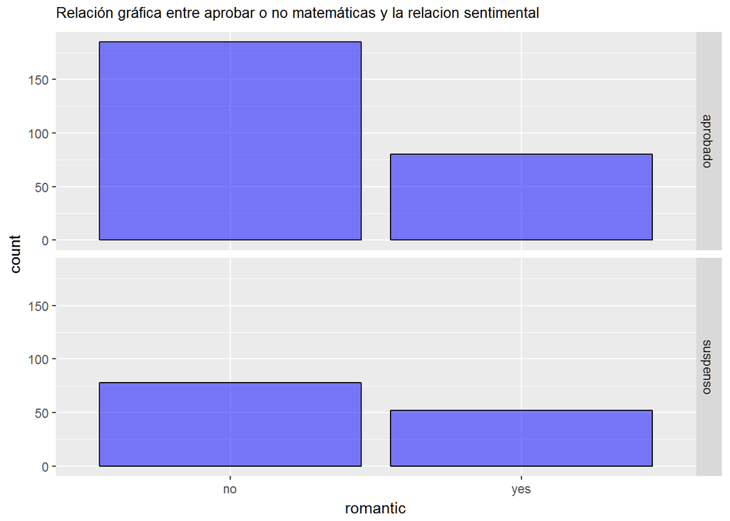

```r
#Hago un gráfico que nos saca la relación que hay entre los aprobados y los suspensos dependiendo de si tienen o no una relación sentimental
ggplot(student.mat.exploratorio, aes(x = romantic)) + geom_bar(colour="black", fill="blue", alpha=.5, stat="count") +
facet_grid(aprobados ~ .) +
ggtitle ("Relación gráfica entre aprobar o no matemáticas y la relacion sentimental") +
theme(plot.title=element_text(vjust = +1.5, size = 10))
```

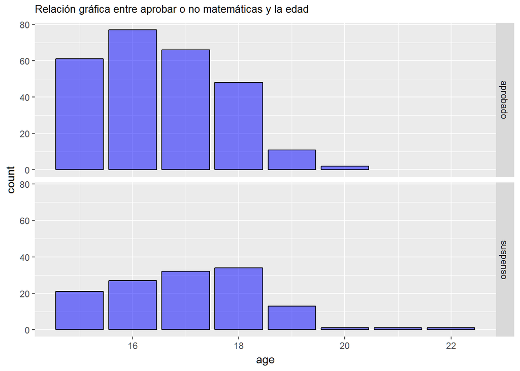

```r
#Hago lo mismo con la edad
ggplot(student.mat.exploratorio, aes(x = age)) + geom_bar(colour="black", fill="blue", alpha=.5, stat="count") +
facet_grid(aprobados ~ .) +
ggtitle ("Relación gráfica entre aprobar o no matemáticas y la edad") +
theme(plot.title=element_text(vjust = +1.5, size = 10))
```

```r
#Comparo la media de las notas finales
aggregate(student.mat.exploratorio["g3"], student.mat.exploratorio["romantic"], mean)
```

```
##   romantic        g3
## 1       no 10.836502
## 2      yes  9.575758
```

```r
aggregate(student.mat.exploratorio["g3"], student.mat.exploratorio["age"], mean)
```

```
##   age        g3
## 1  15 11.256098
## 2  16 11.028846
## 3  17 10.275510
## 4  18  9.548780
## 5  19  8.208333
## 6  20 14.000000
## 7  21  7.000000
## 8  22  8.000000
```

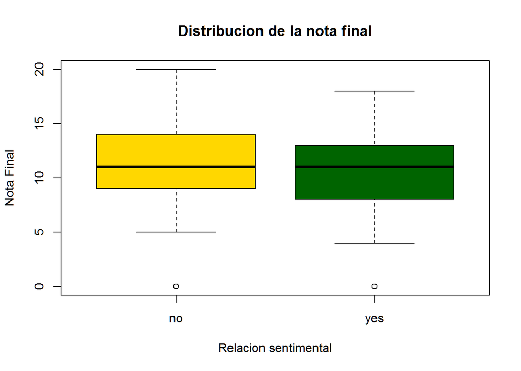

```r
#Hago un gráfico que nos saca la relación que hay entre las notas medias dependiendo de si tienen o no una relación sentimental
boxplot(g3~romantic,data=student.mat.exploratorio, main="Distribucion de la nota final", col=(c("gold","darkgreen")),
    xlab="Relacion sentimental", ylab="Nota Final")
```

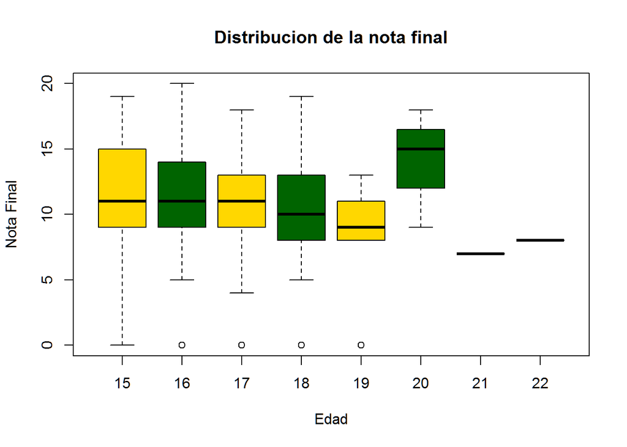

```r
#Hago lo mismo con la edad
boxplot(g3~age,data=student.mat.exploratorio, main="Distribucion de la nota final", col=(c("gold","darkgreen")),
    xlab="Edad", ylab="Nota Final")
```

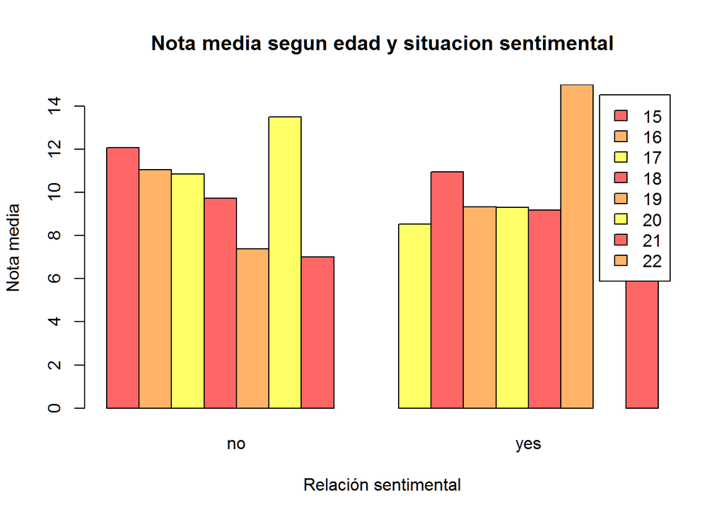

```r
#Convierto la variable aprobados a numerica
student.mat.exploratorio$aprobados <- as.numeric(student.mat.exploratorio$aprobados)

#Hasta aqui he visto graficos que me relacionan la nota final con una de las otras variables, ahora voy a ver como lo hace con las dos a la vez
#Calculo la nota media por edad y relacion sentimental
x <- tapply(student.mat.exploratorio$g3, list(student.mat.exploratorio$age, student.mat.exploratorio$romantic), mean, na.rm=TRUE)

barplot(x,
        legend=TRUE,
        beside=TRUE,
        main="Nota media segun edad y situacion sentimental",
        ylab="Nota media",
        xlab="Relación sentimental",
        col=heat.colors(3,alpha=.6),
        xpd=F)
```

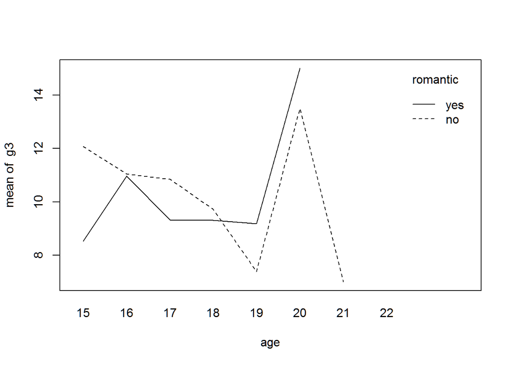

```r
#Este grafico de lineas me muestra gráfico las interacciones entre los dos factores y la nota final
with(student.mat.exploratorio, interaction.plot(age, romantic, g3))
```

## 5. Conclusión

Observando las tablas y los graficos que he realizado llego a siguiente conclusion.

Con las variables que yo he seleccionado no hay una relacion clara con los aprobados ni con la nota media.

Al usar la variable age veo que las notas medias van bajando segun aumenta la edad, exceptuando el caso de la edad igual a 20 que aumenta significativamente. En el caso de aprobados y suspensos no hay una relación clara.

Al combinar ambas variables vemos que la media de la nota final sube y baja sin tener una tendancia clara.

Habria que añadir alguna variable mas al analisis o seleccionar otras variables ya que con estas no se puede sacar ninguna conclusion clara.